# Simple Linear Regression Assignment Solutions

INSOFE Lab Assignment

11 June 2017

**NOTE** Before starting this assignment please remember to clear your environment, you can do that by running the following code chunk

```r
rm(list = ls(all=TRUE))
```

# Combined Cycle Power Plant Data Set

The dataset given to you has been collected from a **Combined Cycle Power Plant** over 6 years (2006-2011).

A combined cycle power plant (CCPP) is composed of gas turbines (GT), steam turbines (ST) and heat recovery steam generators. In a CCPP, the electricity is generated by gas and steam turbines, which are combined in one cycle, and is transferred from one turbine to another. While the Vacuum is colected from and has effect on the Steam Turbine, the other three of the ambient variables effect the GT performance.

The variables in the dataset are as follows:

- **AmbTemp** : Hourly average of ambient Temperature at the plant (Range 1.81°C and 37.11°C)
- **Exvac** : Exhaust Vacuum is pumps air out of the steam turbine (Range 25.36-81.56 cm Hg)
- **AmbPress** : Hourly average of ambient Pressure at the plant (Range 992.89-1033.30 milibar)
- **RelHum** : Hourly average of ambient relative humidity at the plant (Range 25.56% to 100.16%)
- **ElOut** : Net hourly Electrical Energy Output of the plant (Range 420.26-495.76 MW)

# Agenda for the assignment

- Get the data
- Ask interesting questions
- Explore the data
- Clean and Process the Data
- Model the data
- Evaluation and Communication

# Read the Data

- Read in the data and store it in a variable

```r
ccpp_data <- read.csv("ccpp.csv")
```

# Understand the Data

- How many Observations are there in the dataset? What are the data types of the variables?

```r
str(ccpp_data)
```

```
## 'data.frame':    9568 obs. of  5 variables:
##  $ AmbTemp : num  14.96 25.18 5.11 20.86 10.82 ...
##  $ ExVac   : num  41.8 63 39.4 57.3 37.5 ...
##  $ AmbPress: num  1024 1020 1012 1010 1009 ...
##  $ RelHum  : num  73.2 59.1 92.1 76.6 96.6 ...
##  $ ElOut   : num  463 444 489 446 474 ...
```

- Get some descriptive statistics of the variables in the dataset

```r
summary(ccpp_data)
```

```
##     AmbTemp          ExVac          AmbPress          RelHum
##  Min.   : 1.81   Min.   :25.36   Min.   : 992.9   Min.   : 25.56
##  1st Qu.:13.51   1st Qu.:41.70   1st Qu.:1009.1   1st Qu.: 63.37
##  Median :20.34   Median :52.08   Median :1012.9   Median : 74.99
##  Mean   :19.65   Mean   :54.30   Mean   :1013.3   Mean   : 73.32
##  3rd Qu.:25.72   3rd Qu.:66.54   3rd Qu.:1017.3   3rd Qu.: 84.84
##  Max.   :37.11   Max.   :81.56   Max.   :1033.3   Max.   :100.16
##  NA's   :95      NA's   :95      NA's   :95       NA's   :95
##      ElOut
##  Min.   :420.3
##  1st Qu.:439.8
##  Median :451.6
##  Mean   :454.4
##  3rd Qu.:468.4
##  Max.   :495.8
##
```

# Ask Some Questions

# Exploratory Analysis

- Plot the relationships between the explanatory and response variables

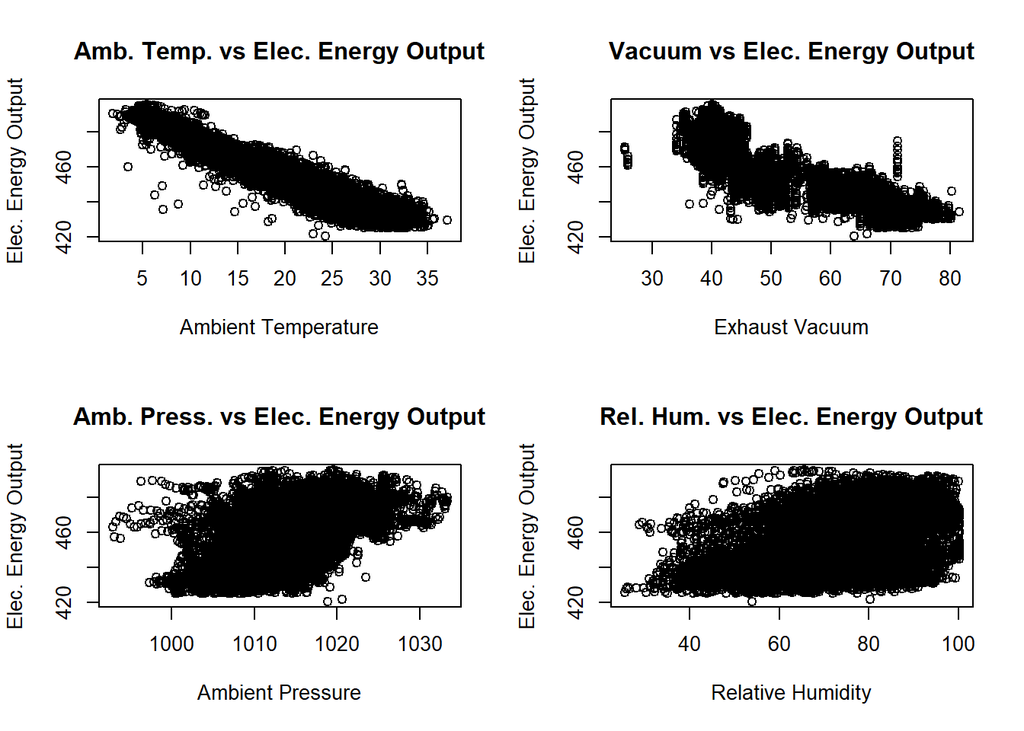

```r
par(mfrow = c(2,2))

plot(ccpp_data$AmbTemp, ccpp_data$ElOut, xlab = "Ambient Temperature", ylab = "Elec. Energy Output" , main = "Amb. Temp. vs Elec. Energy Output")

plot(ccpp_data$ExVac, ccpp_data$ElOut, xlab = "Exhaust Vacuum", ylab = "Elec. Energy Output" , main = "Vacuum vs Elec. Energy Output")

plot(ccpp_data$AmbPress, ccpp_data$ElOut, xlab = "Ambient Pressure", ylab = "Elec. Energy Output" , main = "Amb. Press. vs Elec. Energy Output")

plot(ccpp_data$RelHum, ccpp_data$ElOut, xlab = "Relative Humidity", ylab = "Elec. Energy Output" , main = "Rel. Hum. vs Elec. Energy Output")
```

- Plot a Correlation Plot

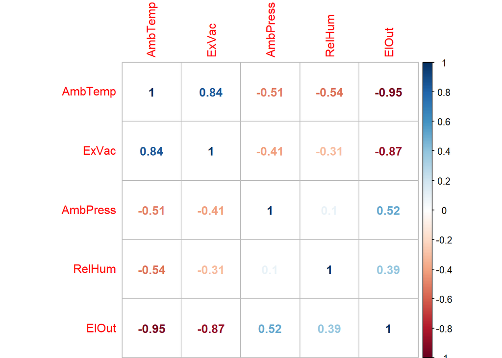

```r
library(corrplot)

corrplot(cor(ccpp_data, use = "complete.obs"), method = "number")
```

# Data Cleaning and Pre-Processing

- Are all the variables in the correct data type?
- Do you need to convert the data type of any of the variables?

```r
# All variables are numeric, no need to convert any the data type of any variable?

str(ccpp_data)
```

```
## 'data.frame':    9568 obs. of  5 variables:
##  $ AmbTemp : num  14.96 25.18 5.11 20.86 10.82 ...
##  $ ExVac   : num  41.8 63 39.4 57.3 37.5 ...
##  $ AmbPress: num  1024 1020 1012 1010 1009 ...
##  $ RelHum  : num  73.2 59.1 92.1 76.6 96.6 ...
##  $ ElOut   : num  463 444 489 446 474 ...
```

- How many Missing Values does the dataset have?

```r
sum(is.na(ccpp_data))
```

```
## [1] 380
```

- Either remove or impute the missing values in the dataset

```r
ccpp_data <- na.omit(ccpp_data)
```

- Standardize (Scale and Center) the explanatory variables

```r
ccpp_std <- scale(ccpp_data[, !(names(ccpp_data) %in% c("ElOut"))])

ccpp_data[, !(names(ccpp_data) %in% c("ElOut"))] <- ccpp_std
```

- Split the data into train and test data sets (70/30)

```r
set.seed(111)

train_rows <- sample(x = 1:nrow(ccpp_data), size = 0.7*nrow(ccpp_data))

train_data <- ccpp_data[train_rows, ]

test_data <- ccpp_data[-train_rows, ]
```

# Build Models

- Build four simple linear regression models
- Note down the coefficients, intercepts, R^2 and p-values of the models you built.
- Plot the residual plots

```r
model1 <- lm(ElOut ~ AmbTemp, data = train_data)

summary(model1)
```

```
##
## Call:
## lm(formula = ElOut ~ AmbTemp, data = train_data)
##
## Residuals:
##     Min      1Q  Median      3Q     Max
## -39.473  -3.697   0.119   3.722  23.050
##
## Coefficients:
##              Estimate Std. Error t value Pr(>|t|)
## (Intercept) 454.26280    0.06600  6882.9   <2e-16 ***
## AmbTemp     -16.28551    0.06623  -245.9   <2e-16 ***
## ---
## Signif. codes:  0 '***' 0.001 '**' 0.01 '*' 0.05 '.' 0.1 ' ' 1
##
## Residual standard error: 5.374 on 6629 degrees of freedom
## Multiple R-squared:  0.9012, Adjusted R-squared:  0.9012
## F-statistic: 6.047e+04 on 1 and 6629 DF,  p-value: < 2.2e-16
```

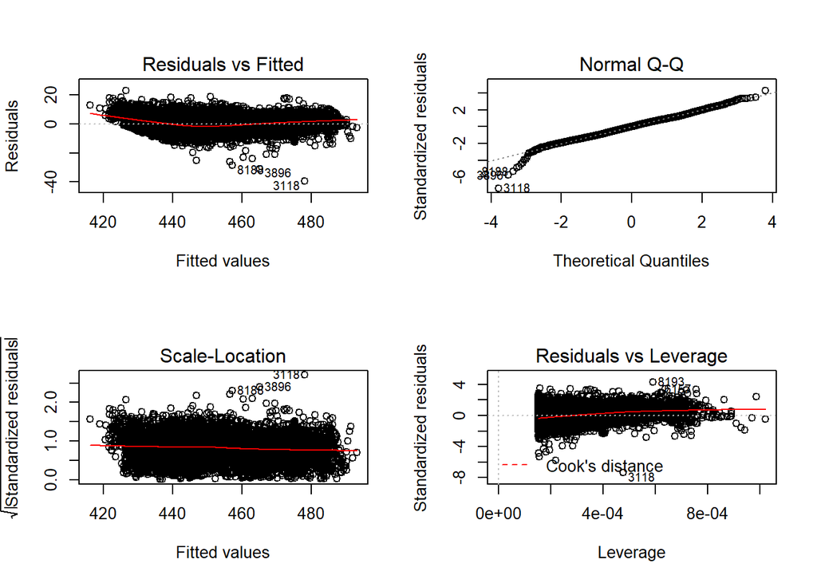

```r
par(mfrow = c(2,2))

plot(model1)
```

```r
model2 <- lm(ElOut ~ ExVac, data = train_data)

summary(model2)
```

```
##
## Call:
## lm(formula = ElOut ~ ExVac, data = train_data)
##
## Residuals:
##     Min      1Q  Median      3Q     Max
## -37.005  -5.387  -0.088   5.409  39.885
##
## Coefficients:
##             Estimate Std. Error t value Pr(>|t|)
## (Intercept) 454.3897     0.1037  4379.8   <2e-16 ***
## ExVac       -14.8017     0.1033  -143.3   <2e-16 ***
## ---
## Signif. codes:  0 '***' 0.001 '**' 0.01 '*' 0.05 '.' 0.1 ' ' 1
##
## Residual standard error: 8.448 on 6629 degrees of freedom
## Multiple R-squared:  0.7559, Adjusted R-squared:  0.7558
## F-statistic: 2.053e+04 on 1 and 6629 DF,  p-value: < 2.2e-16
```

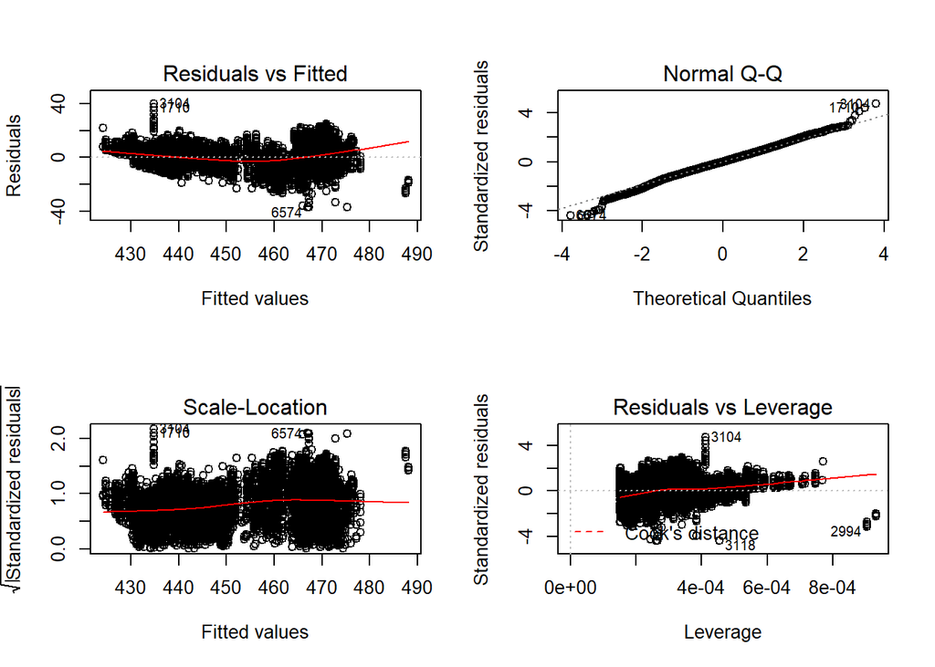

```r
par(mfrow = c(2,2))

plot(model2)
```

```r
model3 <- lm(ElOut ~ AmbPress, data = train_data)

summary(model3)
```

```
##
## Call:
## lm(formula = ElOut ~ AmbPress, data = train_data)
##
## Residuals:
##     Min      1Q  Median      3Q     Max
## -43.482 -11.250  -3.151   9.852  59.703
##
## Coefficients:
##             Estimate Std. Error t value Pr(>|t|)
## (Intercept) 454.3409     0.1813 2506.30   <2e-16 ***
## AmbPress      8.6348     0.1814   47.59   <2e-16 ***
## ---
## Signif. codes:  0 '***' 0.001 '**' 0.01 '*' 0.05 '.' 0.1 ' ' 1
##
## Residual standard error: 14.76 on 6629 degrees of freedom
## Multiple R-squared:  0.2547, Adjusted R-squared:  0.2546
## F-statistic:  2265 on 1 and 6629 DF,  p-value: < 2.2e-16
```

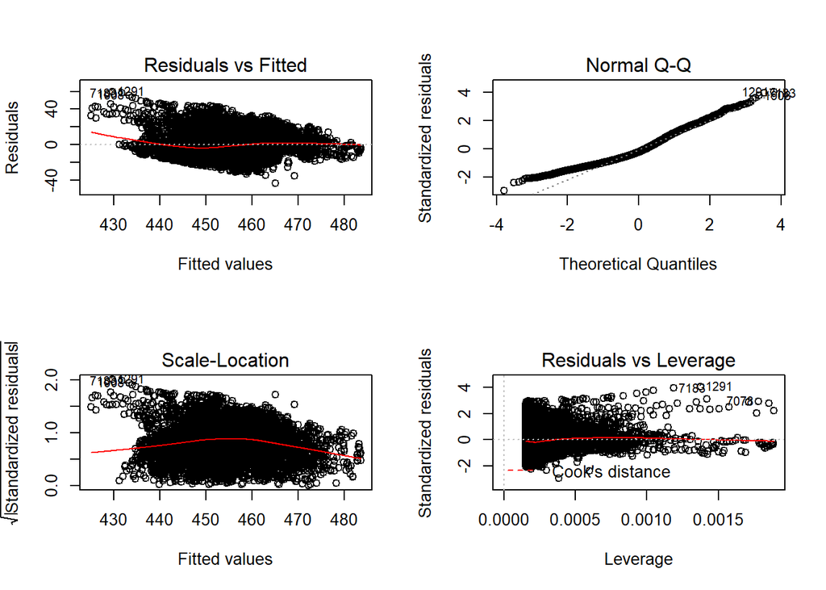

```r
par(mfrow = c(2,2))

plot(model3)
```

```r
model4 <- lm(ElOut ~ RelHum, data = train_data)

summary(model4)
```

```
##
## Call:
## lm(formula = ElOut ~ RelHum, data = train_data)
##
## Residuals:
##     Min      1Q  Median      3Q     Max
## -35.735 -12.499  -1.292  12.117  47.550
##
## Coefficients:
##             Estimate Std. Error t value Pr(>|t|)
## (Intercept) 454.1819     0.1942 2339.01   <2e-16 ***
## RelHum        6.5464     0.1952   33.54   <2e-16 ***
## ---
## Signif. codes:  0 '***' 0.001 '**' 0.01 '*' 0.05 '.' 0.1 ' ' 1
##
## Residual standard error: 15.81 on 6629 degrees of freedom
## Multiple R-squared:  0.1451, Adjusted R-squared:  0.1449
## F-statistic:  1125 on 1 and 6629 DF,  p-value: < 2.2e-16
```

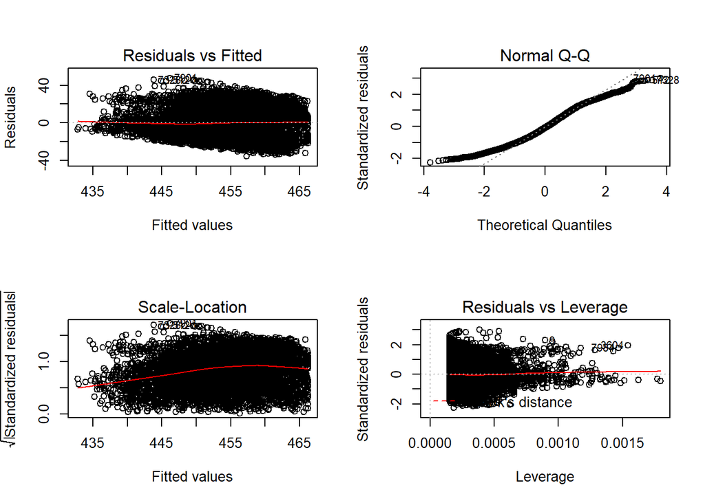

```r
par(mfrow = c(2,2))

plot(model4)
```

# Evaluate the Model

- Select a model by noting the R^2 values of the models you built

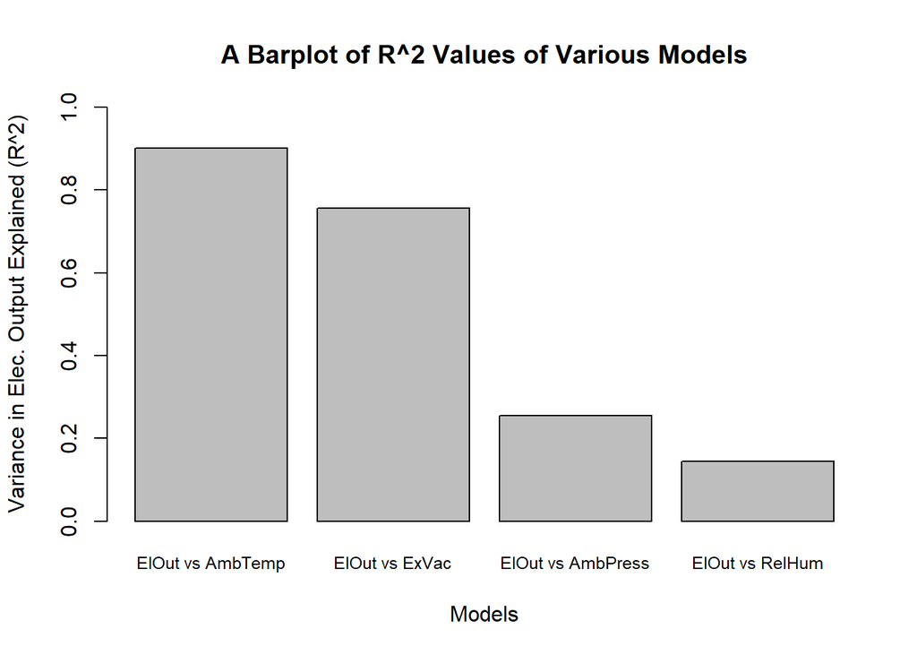

```r
model_names <- c("ElOut vs AmbTemp", "ElOut vs ExVac",
                 "ElOut vs AmbPress", "ElOut vs RelHum")

r2_values <- c(summary(model1)$r.squared, summary(model2)$r.squared,
               summary(model3)$r.squared, summary(model4)$r.squared)

r2 <- cbind(model_names, r2_values)

barplot(r2_values, names.arg = r2[,1], cex.names = 0.78, ylim = c(0, 1),
        main = "A Barplot of R^2 Values of Various Models", xlab = "Models",
        ylab = "Variance in Elec. Output Explained (R^2)")
```

```r
# The best model, by the r2 scores, is the Elec. output vs Ambient Temperature
```

# Report Performace Metrics

- Construct atleast two performance/evaluation metrics

```r
# using the "function()" function, we can create a function which would compute the error if we pass on two parameters to it

mae <- function(actual, predicted){

  error <- actual - predicted

  mean(abs(error))

}
```

```r
mse <- function(actual, predicted){

  error <- actual - predicted

  mean(error^2)

}
```

```r
rmse <- function(actual, predicted){

  error <- actual - predicted

  sqrt(mean(error^2))

}
```

- Predict Test data based on the chosen model

```r
preds <- predict(model1, test_data[, !(names(test_data) %in% c("ElOut"))])
```

- Report the performance and final regression formula of the chosen model *Note:* the formula may change from individual to individual

```r
mae(test_data[, "ElOut"], preds)
```

```
## [1] 4.311509
```

```r
mse(test_data[, "ElOut"], preds)
```

```
## [1] 30.95638
```

```r
rmse(test_data[, "ElOut"], preds)
```

```
## [1] 5.563846
```

The final formula for the chosen regression model is:

$$ElOut = 454.2628 - 16.28551\times (ScaledAmbTemp)$$